```python
import pandas as pd
import seaborn as sns
import numpy as np
import os
import sys
import warnings
import datetime

import plotly.io as pio
import plotly.express as px
import plotly.graph_objects as go

from collections import namedtuple
from matplotlib import pyplot as plt
from dotenv import load_dotenv
from sklearn.preprocessing import MinMaxScaler

sys.path.append("../")

from scripts.distances import haversine_km  # shows an error but its a false positive (we added ../ to path)

data_path = "../data"

pio.renderers.default = "notebook_connected"

load_dotenv()
sns.color_palette('colorblind')
plt.style.use('Solarize_Light2')

# Setting default DPI, pulling it from dotenv if it exists, setting it on 100 if not

try:
    pc_dpi = int(os.getenv('DPI'))
except TypeError:
    pc_dpi = 100
if pc_dpi is None:
    pc_dpi = 100
```

```python
order_data = "../data/optimized/olist_orders.csv"
rfm_dataset = "../pickles/geolocd/cx_rfm.plk"
customer_dataset = "../data/optimized/geoloc_applied/olist_customers.csv"
sellers_dataset = "../data/optimized/geoloc_applied/olist_sellers.csv"
reviews_data = "../data/optimized/olist_reviews.csv"
order_items_data = "../data/optimized/olist_order_items.csv"
```

```python
df_order = pd.read_csv(order_data)
df_rfm = pd.read_pickle(rfm_dataset)
df_cx = pd.read_csv(customer_dataset)
df_sellers = pd.read_csv(sellers_dataset)
df_items = pd.read_csv(order_items_data)
df_reviews = pd.read_csv(reviews_data)
```

# 0 : Getting the variables we need from other datasets

# 1 : Calculate Time deltas for orders

# 2 : Caculate Dist delta of seller - buyers

# 3 : Transitionning from the orders dataset to the cx_rfm dataset.

# 0 : Getting the variables we need from other datasets :

- ## Goals
  - Joining the datasets of order and order_items on order_id to know the distance between the buyer and seller
  - Joining the datasets of order and reviews to know the reviews for reviewed orders.
- ## Whys :
  - Export for further feature engineering
  - Make the datasets less codependents, centralize infos in as few files as possible
  - We will work with only two datasets (orders and cx_rfm)
- ## Hows :
  - > we'll see

## 0.1 : Products and Items for each orders :

### How :

We will use order_id to find items and item sellers in olist_order_items dataset as DataFrame

```python
df_order.head()
```

|  | order_id | customer_id | order_status | order_purchase_dt | order_approved_at | order_delivered_carrier_date | order_delivered_customer_date | order_estimated_delivery_date |
| --- | --- | --- | --- | --- | --- | --- | --- | --- |
| 0 | 1 | 70297 | delivered | 2017-10-02 10:56:33 | 2017-10-02 11:07:15 | 2017-10-04 19:55:00 | 2017-10-10 21:25:13 | 2017-10-18 |
| 1 | 2 | 77028 | delivered | 2018-07-24 20:41:37 | 2018-07-26 03:24:27 | 2018-07-26 14:31:00 | 2018-08-07 15:27:45 | 2018-08-13 |
| 2 | 3 | 555 | delivered | 2018-08-08 08:38:49 | 2018-08-08 08:55:23 | 2018-08-08 13:50:00 | 2018-08-17 18:06:29 | 2018-09-04 |
| 3 | 4 | 61082 | delivered | 2017-11-18 19:28:06 | 2017-11-18 19:45:59 | 2017-11-22 13:39:59 | 2017-12-02 00:28:42 | 2017-12-15 |
| 4 | 5 | 67264 | delivered | 2018-02-13 21:18:39 | 2018-02-13 22:20:29 | 2018-02-14 19:46:34 | 2018-02-16 18:17:02 | 2018-02-26 |

```python
df_items.head()
```

|  | order_id | order_item_id | product_id | seller_id | shipping_limit_date | price | freight_value |
| --- | --- | --- | --- | --- | --- | --- | --- |
| 0 | 85268 | 1 | 25866 | 514 | 2017-09-19 09:45:35 | 58.90 | 13.29 |
| 1 | 71854 | 1 | 27231 | 472 | 2017-05-03 11:05:13 | 239.90 | 19.93 |
| 2 | 6299 | 1 | 22625 | 1825 | 2018-01-18 14:48:30 | 199.00 | 17.87 |
| 3 | 22551 | 1 | 15404 | 2024 | 2018-08-15 10:10:18 | 12.99 | 12.79 |
| 4 | 5248 | 1 | 8863 | 1598 | 2017-02-13 13:57:51 | 199.90 | 18.14 |

```python
# Checking if df_items contains duplicated order_id, if not, using order id as index
df_items["order_id"].duplicated().sum()
```

```
13984
```

> That was a long shot anyway, but we cannot use order_id as index for df_items

```python
# Making a selection on items :
# Already in RFM, shipping date is not relevant

df_items = df_items.drop(columns=["shipping_limit_date", "price", "freight_value", "order_item_id"])

df_items.sort_values(by="order_id", inplace=True)
```

### Getting the product_list and seller_list for each order

```python
df_order["product_list"] = np.dtype("object")
df_order["seller_list"] = np.dtype("object")

order_ids = df_order["order_id"].values

for current_order in order_ids:
    order_idx = df_order[df_order["order_id"] == current_order].index[0]
    items = df_items[df_items["order_id"] == current_order]
    df_order.at[order_idx, "product_list"] = list(items["product_id"].values)
    df_order.at[order_idx, "seller_list"] = list(items["seller_id"].values)
```

```python
df_order.head()
```

|  | order_id | customer_id | order_status | order_purchase_dt | order_approved_at | order_delivered_carrier_date | order_delivered_customer_date | order_estimated_delivery_date | product_list | seller_list |
| --- | --- | --- | --- | --- | --- | --- | --- | --- | --- | --- |
| 0 | 1 | 70297 | delivered | 2017-10-02 10:56:33 | 2017-10-02 11:07:15 | 2017-10-04 19:55:00 | 2017-10-10 21:25:13 | 2017-10-18 | [2350] | [560] |
| 1 | 2 | 77028 | delivered | 2018-07-24 20:41:37 | 2018-07-26 03:24:27 | 2018-07-26 14:31:00 | 2018-08-07 15:27:45 | 2018-08-13 | [20551] | [550] |
| 2 | 3 | 555 | delivered | 2018-08-08 08:38:49 | 2018-08-08 08:55:23 | 2018-08-08 13:50:00 | 2018-08-17 18:06:29 | 2018-09-04 | [12229] | [2618] |
| 3 | 4 | 61082 | delivered | 2017-11-18 19:28:06 | 2017-11-18 19:45:59 | 2017-11-22 13:39:59 | 2017-12-02 00:28:42 | 2017-12-15 | [29926] | [2990] |
| 4 | 5 | 67264 | delivered | 2018-02-13 21:18:39 | 2018-02-13 22:20:29 | 2018-02-14 19:46:34 | 2018-02-16 18:17:02 | 2018-02-26 | [11901] | [1497] |

> Looks good, now, we know that an order can contain multiple products, but can an order mobilize multiple sellers ? Let's check

```python
multiple_sellers = 0

for tuple in df_order.itertuples():
    if len(tuple.seller_list) > 1:
        multiple_sellers += 1

print(f"there are {multiple_sellers} orders with multiple sellers")
```

```
there are 9803 orders with multiple sellers
```

For now : we will take ∆avg for each order.  
*In it's own section*

## 0.2 : Geolocs from sellers and buyers for each order :

- We will use the impractical tuple (lat/lon) and unpack it when we will have to plot on a map.
- Buyer will have only one geoloc, seller_list will be a list of lat/lon

> First let's take a look

```python
df_order.head()
```

|  | order_id | customer_id | order_status | order_purchase_dt | order_approved_at | order_delivered_carrier_date | order_delivered_customer_date | order_estimated_delivery_date | product_list | seller_list |
| --- | --- | --- | --- | --- | --- | --- | --- | --- | --- | --- |
| 0 | 1 | 70297 | delivered | 2017-10-02 10:56:33 | 2017-10-02 11:07:15 | 2017-10-04 19:55:00 | 2017-10-10 21:25:13 | 2017-10-18 | [2350] | [560] |
| 1 | 2 | 77028 | delivered | 2018-07-24 20:41:37 | 2018-07-26 03:24:27 | 2018-07-26 14:31:00 | 2018-08-07 15:27:45 | 2018-08-13 | [20551] | [550] |
| 2 | 3 | 555 | delivered | 2018-08-08 08:38:49 | 2018-08-08 08:55:23 | 2018-08-08 13:50:00 | 2018-08-17 18:06:29 | 2018-09-04 | [12229] | [2618] |
| 3 | 4 | 61082 | delivered | 2017-11-18 19:28:06 | 2017-11-18 19:45:59 | 2017-11-22 13:39:59 | 2017-12-02 00:28:42 | 2017-12-15 | [29926] | [2990] |
| 4 | 5 | 67264 | delivered | 2018-02-13 21:18:39 | 2018-02-13 22:20:29 | 2018-02-14 19:46:34 | 2018-02-16 18:17:02 | 2018-02-26 | [11901] | [1497] |

```python
df_cx.head()
```

|  | customer_id | customer_unique_id | customer_zip_code_prefix | customer_city | customer_state | lat | lon |
| --- | --- | --- | --- | --- | --- | --- | --- |
| 0 | 1 | 1 | 14409 | franca | SP | -20.509898 | -47.397866 |
| 1 | 651 | 651 | 14409 | franca | SP | -20.509898 | -47.397866 |
| 2 | 3980 | 3973 | 14409 | franca | SP | -20.509898 | -47.397866 |
| 3 | 12080 | 12022 | 14409 | franca | SP | -20.509898 | -47.397866 |
| 4 | 12642 | 12581 | 14409 | franca | SP | -20.509898 | -47.397866 |

```python
df_sellers.head()
```

|  | seller_id | seller_zip_code_prefix | seller_city | seller_state | lat | lon |
| --- | --- | --- | --- | --- | --- | --- |
| 0 | 1 | 13023 | campinas | SP | -22.898536 | -47.063125 |
| 1 | 1811 | 13023 | campinas | SP | -22.898536 | -47.063125 |
| 2 | 2 | 13844 | mogi guacu | SP | -22.382941 | -46.946641 |
| 3 | 3 | 20031 | rio de janeiro | RJ | -22.910641 | -43.176510 |
| 4 | 1227 | 20031 | rio de janeiro | RJ | -22.910641 | -43.176510 |

### How :

Using the same method as in the order/items, we will find the lat/lon tuple for each seller and buyer using : customer_id and seller_id

```python
df_order["geoloc_cx"] = np.dtype("object")

cx_ids = df_order["customer_id"].values

for current_order in order_ids:
    order_idx = df_order[df_order["order_id"] == current_order].index[0]
    cx_id = df_order[df_order["order_id"] == current_order]["customer_id"].values[0]
    cx_row = df_cx[df_cx["customer_id"] == cx_id]
    lat, lon = float(cx_row["lat"].values[0]) , float(cx_row["lon"].values[0])
    lat_lon = (lat, lon)
    df_order.at[order_idx, "geoloc_cx"] = lat_lon
```

```python
df_order["geoloc_sellers_list"] = np.dtype("object")

sellers_ids = df_order[df_order["order_id"] == current_order].index[0]

for current_order in order_ids:

    order_idx = df_order[df_order["order_id"] == current_order].index[0]
    sellers_id_list = list(df_order[df_order["order_id"] == current_order]["seller_list"].values[0])
    lat_lon_list = []

    for seller_id in sellers_id_list:
        seller_row = df_sellers[df_sellers["seller_id"] == seller_id]
        lat, lon = float(seller_row["lat"].values[0]), float(seller_row["lon"].values[0])
        lat_lon = (lat, lon)
        lat_lon_list.append(lat_lon)
        del lat_lon
    df_order.at[order_idx, "geoloc_sellers_list"] = lat_lon_list
```

```python
df_order.head()
```

|  | order_id | customer_id | order_status | order_purchase_dt | order_approved_at | order_delivered_carrier_date | order_delivered_customer_date | order_estimated_delivery_date | product_list | seller_list | geoloc_cx | geoloc_sellers_list |
| --- | --- | --- | --- | --- | --- | --- | --- | --- | --- | --- | --- | --- |
| 0 | 1 | 70297 | delivered | 2017-10-02 10:56:33 | 2017-10-02 11:07:15 | 2017-10-04 19:55:00 | 2017-10-10 21:25:13 | 2017-10-18 | [2350] | [560] | (-23.57480921065843, -46.587471259651394) | [(-23.68011442853022, -46.4524537436668)] |
| 1 | 2 | 77028 | delivered | 2018-07-24 20:41:37 | 2018-07-26 03:24:27 | 2018-07-26 14:31:00 | 2018-08-07 15:27:45 | 2018-08-13 | [20551] | [550] | (-12.169859806853127, -44.988369250768905) | [(-19.81011863229108, -43.98472732006267)] |
| 2 | 3 | 555 | delivered | 2018-08-08 08:38:49 | 2018-08-08 08:55:23 | 2018-08-08 13:50:00 | 2018-08-17 18:06:29 | 2018-09-04 | [12229] | [2618] | (-16.74633718068107, -48.51462382317262) | [(-21.36235769739203, -48.232975701561735)] |
| 3 | 4 | 61082 | delivered | 2017-11-18 19:28:06 | 2017-11-18 19:45:59 | 2017-11-22 13:39:59 | 2017-12-02 00:28:42 | 2017-12-15 | [29926] | [2990] | (-5.767733285303072, -35.275466808694375) | [(-19.840168078827364, -43.92329932223438)] |
| 4 | 5 | 67264 | delivered | 2018-02-13 21:18:39 | 2018-02-13 22:20:29 | 2018-02-14 19:46:34 | 2018-02-16 18:17:02 | 2018-02-26 | [11901] | [1497] | (-23.675037359389663, -46.524784094929146) | [(-23.551706513599484, -46.260979398542325)] |

> Thats nice we can work with that

## 0.3 : Reviews for all orders :

### How :

- Similar method to above, only with df_reviews
- Selecting what we want to know from review with df.head()

> *(note to self : work on a generic way of approaching the simple problem (not the list of lists) with concurrent.futures)*

```python
# Lets select our variables first :

df_reviews.head()
```

|  | review_id | order_id | review_score | review_comment_title | review_comment_message | review_creation_date | review_answer_dt |
| --- | --- | --- | --- | --- | --- | --- | --- |
| 0 | 1 | 1872 | 4 | NaN | NaN | 2018-01-18 00:00:00 | 2018-01-18 21:46:59 |
| 1 | 2 | 90489 | 5 | NaN | NaN | 2018-03-10 00:00:00 | 2018-03-11 03:05:13 |
| 2 | 3 | 78883 | 5 | NaN | NaN | 2018-02-17 00:00:00 | 2018-02-18 14:36:24 |
| 3 | 4 | 27558 | 5 | NaN | Recebi bem antes do prazo estipulado. | 2017-04-21 00:00:00 | 2017-04-21 22:02:06 |
| 4 | 5 | 79506 | 5 | NaN | Parabéns lojas lannister adorei comprar pela I... | 2018-03-01 00:00:00 | 2018-03-02 10:26:53 |

```python
df_reviews.info()
```

```
<class 'pandas.core.frame.DataFrame'>
RangeIndex: 99224 entries, 0 to 99223
Data columns (total 7 columns):
 #   Column                  Non-Null Count  Dtype
---  ------                  --------------  -----
 0   review_id               99224 non-null  int64
 1   order_id                99224 non-null  int64
 2   review_score            99224 non-null  int64
 3   review_comment_title    11568 non-null  object
 4   review_comment_message  40977 non-null  object
 5   review_creation_date    99224 non-null  object
 6   review_answer_dt        99224 non-null  object
dtypes: int64(3), object(4)
memory usage: 5.3+ MB
```

> We are mainly interested in review score, but we can also create a boolean variable to check whether or not the review was assorted with a comment or not. We can debate whether or not the lenght of the review is important. In the future we can also think about using NLP engines such as GPT-3 to detect the "tone" of the answer and the topics approached. This would be, however, a little heavy for the model and a lot a work to put into place

**For now**

- Create the boolean value for comment in reviews directly
- Create a new boolean assign boolean values : has_rating and has_comment
- **Maybe** (check with team) create a boolean value to check if, in the case of comment, an Olist support agent has replied. Could be relevant (we like to know that our comment was read or our complaint heard/taken care of). It isnt explicit on the dataset if this is a support agent who replied or the Cx who updated the review. Will check online

**!!!Note!!!** : after online (Kaggle, cf. sources) check : review_answer_timestamp : Shows satisfaction survey answer timestamp., no support agent involved as far as I can see. Last point is irrelevant but could be a nice addition for Olist's databases in the future.

```python
def has_comment(row) -> bool:
    """
    - Determines if a review is assorted with a comment/message (returns boolean)
    - For dataset : reviews
    """

    if not pd.isna(row["review_comment_message"]):
        return True
    elif pd.isna(row["review_comment_message"]):
        return False
```

```python
# lets drop the non useful columns :
df_reviews.drop(columns=["review_answer_dt", "review_creation_date", "review_comment_title"], inplace=True)

df_reviews.head()
```

|  | review_id | order_id | review_score | review_comment_message |
| --- | --- | --- | --- | --- |
| 0 | 1 | 1872 | 4 | NaN |
| 1 | 2 | 90489 | 5 | NaN |
| 2 | 3 | 78883 | 5 | NaN |
| 3 | 4 | 27558 | 5 | Recebi bem antes do prazo estipulado. |
| 4 | 5 | 79506 | 5 | Parabéns lojas lannister adorei comprar pela I... |

#### Plotting the ratings as barplot out of curiosity :

In general, only two kind of people rate/comment : the really happy ones and the really disappointed ones. If this is true here, we should see a disproportional amount of good (5) and bad (1, 2), a little bit of 4s but a very low amount of 3s. Let's see

```python
# Forcing dtypes :
df_reviews["review_score"] = df_reviews["review_score"].astype(int)
```

```python
cmap = {1: "#810000", 2: "red", 3: "royalblue", 4: "navy", 5: "#003153"}
title = "Distribution of ratings in the reviews given by users"

fig = px.histogram(df_reviews, x="review_score", color="review_score", color_discrete_map=cmap, title=title)

fig.update_layout(margin={"b": 25, "t": 25, "r": 25, "l": 25})
fig.update_layout(title_y=0.95, title_x=0.1)
fig.update_layout(font_color="black")

fig.show()
```

[interactive chart not shown]

Let's place our boolean in review :

```python
df_reviews["has_comment"] = df_reviews.apply(has_comment, axis=1)
```

```python
df_reviews.head()
```

|  | review_id | order_id | review_score | review_comment_message | has_comment |
| --- | --- | --- | --- | --- | --- |
| 0 | 1 | 1872 | 4 | NaN | False |
| 1 | 2 | 90489 | 5 | NaN | False |
| 2 | 3 | 78883 | 5 | NaN | False |
| 3 | 4 | 27558 | 5 | Recebi bem antes do prazo estipulado. | True |
| 4 | 5 | 79506 | 5 | Parabéns lojas lannister adorei comprar pela I... | True |

```python
df_order["review_score"] = np.dtype("int")
df_order["has_rating"] = np.dtype("bool")
df_order["has_comment"] = np.dtype("bool")

order_ids = df_order["order_id"].values

for current_order in order_ids:
    order_idx = df_order[df_order["order_id"] == current_order].index[0]
    try:
        review = df_reviews[df_reviews["order_id"] == current_order]
        df_order.at[order_idx, "review_score"] = review["review_score"].values[0]
        df_order.at[order_idx, "has_rating"] = True
        if any(review["has_comment"]):
            df_order.at[order_idx, "has_comment"] = True
        else:
            df_order.at[order_idx, "has_comment"] = False

    except IndexError:
        df_order.at[order_idx, "review_score"] = np.nan
        df_order.at[order_idx, "has_rating"] = False
        df_order.at[order_idx, "has_comment"] = False
```

```python
df_order.head()
```

|  | order_id | customer_id | order_status | order_purchase_dt | order_approved_at | order_delivered_carrier_date | order_delivered_customer_date | order_estimated_delivery_date | product_list | seller_list | geoloc_cx | geoloc_sellers_list | review_score | has_rating | has_comment |
| --- | --- | --- | --- | --- | --- | --- | --- | --- | --- | --- | --- | --- | --- | --- | --- |
| 0 | 1 | 70297 | delivered | 2017-10-02 10:56:33 | 2017-10-02 11:07:15 | 2017-10-04 19:55:00 | 2017-10-10 21:25:13 | 2017-10-18 | [2350] | [560] | (-23.57480921065843, -46.587471259651394) | [(-23.68011442853022, -46.4524537436668)] | 4 | True | True |
| 1 | 2 | 77028 | delivered | 2018-07-24 20:41:37 | 2018-07-26 03:24:27 | 2018-07-26 14:31:00 | 2018-08-07 15:27:45 | 2018-08-13 | [20551] | [550] | (-12.169859806853127, -44.988369250768905) | [(-19.81011863229108, -43.98472732006267)] | 4 | True | True |
| 2 | 3 | 555 | delivered | 2018-08-08 08:38:49 | 2018-08-08 08:55:23 | 2018-08-08 13:50:00 | 2018-08-17 18:06:29 | 2018-09-04 | [12229] | [2618] | (-16.74633718068107, -48.51462382317262) | [(-21.36235769739203, -48.232975701561735)] | 5 | True | False |
| 3 | 4 | 61082 | delivered | 2017-11-18 19:28:06 | 2017-11-18 19:45:59 | 2017-11-22 13:39:59 | 2017-12-02 00:28:42 | 2017-12-15 | [29926] | [2990] | (-5.767733285303072, -35.275466808694375) | [(-19.840168078827364, -43.92329932223438)] | 5 | True | True |
| 4 | 5 | 67264 | delivered | 2018-02-13 21:18:39 | 2018-02-13 22:20:29 | 2018-02-14 19:46:34 | 2018-02-16 18:17:02 | 2018-02-26 | [11901] | [1497] | (-23.675037359389663, -46.524784094929146) | [(-23.551706513599484, -46.260979398542325)] | 5 | True | False |

# 1 : Calculate Time deltas for orders

## 1.1 : Calculate Time delta of delivery for delivered orders (status = delivered)

## 1.2 : Calculate Time delta of expected/delivered orders + booleans

## 1.1 : Calculate Time delta of delivery for delivered orders (status = delivered)

### 1 : How ?

We apply only that ∆ on delivered orders, if the order["order_delivered_customer_date"] is blank, function will skip it

### 2 : Applied to Cx :

We will calculate the average ∆T for each Cx using the list of orders in df_rfm : for Cx with exactly one order, this will be of no consequence as ∆T will be from only one order, but for Cxs w/ multiple orders, we will take the avg. ∆. For Cx w/ no ∆ present on orders (if their order status is not "deliverd"), see point 3.

### 3 : Remaining values :

No modification of missing values until the merger with the rfm dataset -- The merger then will use a mean inputer while taking into account the cluster of the customer

```python
df_order.head()
```

|  | order_id | customer_id | order_status | order_purchase_dt | order_approved_at | order_delivered_carrier_date | order_delivered_customer_date | order_estimated_delivery_date | product_list | seller_list | geoloc_cx | geoloc_sellers_list | review_score | has_rating | has_comment |
| --- | --- | --- | --- | --- | --- | --- | --- | --- | --- | --- | --- | --- | --- | --- | --- |
| 0 | 1 | 70297 | delivered | 2017-10-02 10:56:33 | 2017-10-02 11:07:15 | 2017-10-04 19:55:00 | 2017-10-10 21:25:13 | 2017-10-18 | [2350] | [560] | (-23.57480921065843, -46.587471259651394) | [(-23.68011442853022, -46.4524537436668)] | 4 | True | True |
| 1 | 2 | 77028 | delivered | 2018-07-24 20:41:37 | 2018-07-26 03:24:27 | 2018-07-26 14:31:00 | 2018-08-07 15:27:45 | 2018-08-13 | [20551] | [550] | (-12.169859806853127, -44.988369250768905) | [(-19.81011863229108, -43.98472732006267)] | 4 | True | True |
| 2 | 3 | 555 | delivered | 2018-08-08 08:38:49 | 2018-08-08 08:55:23 | 2018-08-08 13:50:00 | 2018-08-17 18:06:29 | 2018-09-04 | [12229] | [2618] | (-16.74633718068107, -48.51462382317262) | [(-21.36235769739203, -48.232975701561735)] | 5 | True | False |
| 3 | 4 | 61082 | delivered | 2017-11-18 19:28:06 | 2017-11-18 19:45:59 | 2017-11-22 13:39:59 | 2017-12-02 00:28:42 | 2017-12-15 | [29926] | [2990] | (-5.767733285303072, -35.275466808694375) | [(-19.840168078827364, -43.92329932223438)] | 5 | True | True |
| 4 | 5 | 67264 | delivered | 2018-02-13 21:18:39 | 2018-02-13 22:20:29 | 2018-02-14 19:46:34 | 2018-02-16 18:17:02 | 2018-02-26 | [11901] | [1497] | (-23.675037359389663, -46.524784094929146) | [(-23.551706513599484, -46.260979398542325)] | 5 | True | False |

```python
# Checkings for NAs in "order_delivered_customer_date" & "order_purchase_dt"
temp = df_order[df_order["order_status"] == "delivered"]

delivered_na_count = temp["order_delivered_customer_date"].isna().sum()
purchase_dt_na_count = temp["order_purchase_dt"].isna().sum()

print(f"There is {delivered_na_count} values missing in order_delivered_customer_date")
print(f"There is {purchase_dt_na_count} values missing in order_purchase_dt")

del temp  # Flush
```

```
There is 8 values missing in order_delivered_customer_date
There is 0 values missing in order_purchase_dt
```

There are 8 values missing in order_delivered_customer_date, likely the order was delivered too recently at sql dump time. Regardless, ignoring.

```python
def calc_delta_t(row):
    """
    If status of order is delivered, returns delta between the delivery and order.
    If any data is missing for this operation to work, returns nan
    """
    if row["order_status"] == "delivered":

        delivered_at = pd.to_datetime(row["order_delivered_customer_date"])
        ordered_at = pd.to_datetime(row["order_purchase_dt"])

        if pd.isna(delivered_at) or pd.isna(ordered_at):
            return np.nan
        elif not pd.isna(delivered_at) and not pd.isna(ordered_at):
            return delivered_at - ordered_at
    else:
        return np.nan
```

```python
df_order["delta_delivery"] = df_order.apply(calc_delta_t, axis=1)
```

```python
# checking :

df_order["delta_delivery"].head()
```

```
0    8 days 10:28:40
1   13 days 18:46:08
2    9 days 09:27:40
3   13 days 05:00:36
4    2 days 20:58:23
Name: delta_delivery, dtype: timedelta64[ns]
```

```python
# checking number of nans and the number of not delivered orders, should be pretty similar :

na_delta_del = df_order['delta_delivery'].isna().sum()
not_delivered_len = len(df_order[df_order['order_status'] != 'delivered'])
print(f"{na_delta_del} missing values in Delta Delivery")
print(f"{not_delivered_len} missing values in packages not delivered")

print(f"delta_del_na - not_delivered = {na_delta_del - not_delivered_len}")
```

```
2971 missing values in Delta Delivery
2963 missing values in packages not delivered
delta_del_na - not_delivered = 8
```

We can see the same, expected number of delivered packages without a delta delivery. As predicted

## 1.2 : Calculate Time delta of expected/delivered orders + booleans

- Goals : We want to establish, for packages delivered, the difference between the expected date of delivery and the actual delivery date.  
  It might be a good indicator of satisfaction : we are happy if our package is early/on time, and not happy if we are delivered late.
- Creation of booleans : EarlyOrOnTime : True for early and on time , False for late

```python
def calc_expect_delta(row):
    """
    Calculates the time delta between the expected delivery date, keeping y, m, d in order_delivered_customer_date
    3 cases if not nan:
    - value = 0 --> On time
    - value < 0 --> Early
    - Value > 0 --> Late

    Returns : pd.TimeDelta or np.nan
    """

    if row["order_status"] == "delivered":

        delivered_at_full = pd.to_datetime(row["order_delivered_customer_date"])
        expected_at = pd.to_datetime(row["order_estimated_delivery_date"])

        if pd.isna(delivered_at_full) or pd.isna(expected_at):
            return np.nan
        elif not pd.isna(delivered_at_full) and not pd.isna(expected_at):

            delivered_at_trunc = pd.to_datetime(
                datetime.date(
                        int(delivered_at_full.year),
                        int(delivered_at_full.month),
                        int(delivered_at_full.day)
                    )
                )
            return delivered_at_trunc - expected_at
    else:
        return np.nan


def on_time_late(row):
    """
    Returns True if package arrived before or on the predicted day, and False if package is late
    """

    if row["order_status"] == "delivered":
        delta_days = row['expectation_delta'].days
        if not pd.isna(row["expectation_delta"]):
            if delta_days <= 0:
                return True
            elif delta_days > 0:
                return False
```

```python
df_order["expectation_delta"] = df_order.apply(calc_expect_delta, axis=1)
```

```python
deltas = df_order["expectation_delta"].value_counts().to_dict()
deltas = dict(sorted(deltas.items()))

delta_days = {}

for key, value in deltas.items():
    delta_days[key.days] = value
```

It seems we have a lot of extremes. Plotting in bars to see clearly

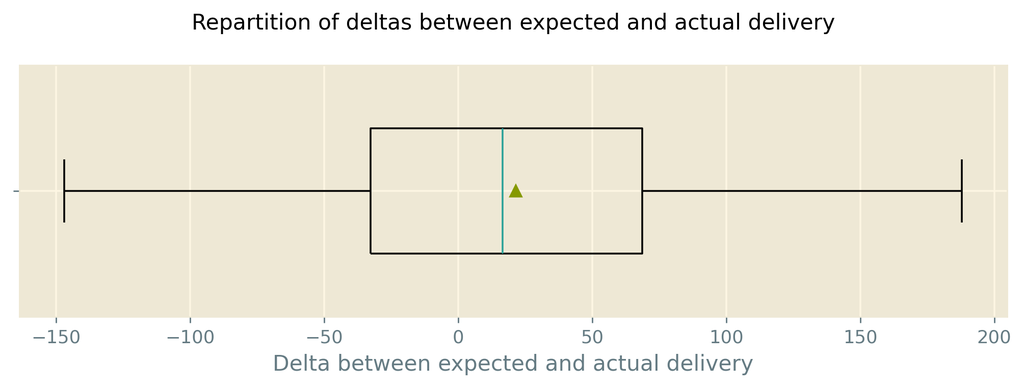

```python
fig, (ax1) = plt.subplots(
    ncols=1,
    nrows=1,
    figsize=(8, 3),
    dpi=pc_dpi,
)

ax1.boxplot(x=delta_days, vert=False, showfliers=True, showmeans=True, widths=.5)


###
# Titles/Lables
ax1.set_yticklabels([])
ax1.set_xlabel("Delta between expected and actual delivery")
fig.suptitle("Repartition of deltas between expected and actual delivery")
#
###

fig.tight_layout()
plt.show()
```

```python
# Boolean and we're done :

df_order["early_on_time"] = df_order.apply(on_time_late, axis=1)
```

```python
df_order["expectation_delta"].describe(percentiles=([.001, .1, .25, .75, .9, .95, .998]))
```

```
count                           96470
mean     -12 days +02:58:43.200995128
std        10 days 04:22:13.878393156
min               -147 days +00:00:00
0.1%               -51 days +00:00:00
10%                -22 days +00:00:00
25%                -17 days +00:00:00
50%                -12 days +00:00:00
75%                 -7 days +00:00:00
90%                 -2 days +00:00:00
95%                   3 days 00:00:00
99.8%                41 days 00:00:00
max                 188 days 00:00:00
Name: expectation_delta, dtype: object
```

After looking up the quantiles, 0.1%, 99.9%

> We will discard these extreme cases. (above 0.1% and under 99.9%)

```python
p_0_1 = df_order["expectation_delta"].quantile(0.001) # Getting the value @ 0.1%
p_99_9 = df_order["expectation_delta"].quantile(0.999) # Getting the value @ 99.9%

remove_low = df_order[df_order["expectation_delta"].lt(p_0_1) & df_order["expectation_delta"].notna()].index.tolist()
remove_high = df_order[df_order["expectation_delta"].gt(p_99_9) & df_order["expectation_delta"].notna()].index.tolist()

remove_high_low = remove_high + remove_low

print(f"We will remove {len(remove_high_low)} orders from the dataframe.")
```

```
We will remove 191 orders from the dataframe.
```

```python
df_order = df_order.drop(index=remove_high_low)
```

```python
# Redoing the index

df_order.reset_index(drop=True, inplace=True)
```

```python
# Checking- check True :

df_order[df_order["early_on_time"] == True].head()
```

|  | order_id | customer_id | order_status | order_purchase_dt | order_approved_at | order_delivered_carrier_date | order_delivered_customer_date | order_estimated_delivery_date | product_list | seller_list | geoloc_cx | geoloc_sellers_list | review_score | has_rating | has_comment | delta_delivery | expectation_delta | early_on_time |
| --- | --- | --- | --- | --- | --- | --- | --- | --- | --- | --- | --- | --- | --- | --- | --- | --- | --- | --- |
| 0 | 1 | 70297 | delivered | 2017-10-02 10:56:33 | 2017-10-02 11:07:15 | 2017-10-04 19:55:00 | 2017-10-10 21:25:13 | 2017-10-18 | [2350] | [560] | (-23.57480921065843, -46.587471259651394) | [(-23.68011442853022, -46.4524537436668)] | 4 | True | True | 8 days 10:28:40 | -8 days | True |
| 1 | 2 | 77028 | delivered | 2018-07-24 20:41:37 | 2018-07-26 03:24:27 | 2018-07-26 14:31:00 | 2018-08-07 15:27:45 | 2018-08-13 | [20551] | [550] | (-12.169859806853127, -44.988369250768905) | [(-19.81011863229108, -43.98472732006267)] | 4 | True | True | 13 days 18:46:08 | -6 days | True |
| 2 | 3 | 555 | delivered | 2018-08-08 08:38:49 | 2018-08-08 08:55:23 | 2018-08-08 13:50:00 | 2018-08-17 18:06:29 | 2018-09-04 | [12229] | [2618] | (-16.74633718068107, -48.51462382317262) | [(-21.36235769739203, -48.232975701561735)] | 5 | True | False | 9 days 09:27:40 | -18 days | True |
| 3 | 4 | 61082 | delivered | 2017-11-18 19:28:06 | 2017-11-18 19:45:59 | 2017-11-22 13:39:59 | 2017-12-02 00:28:42 | 2017-12-15 | [29926] | [2990] | (-5.767733285303072, -35.275466808694375) | [(-19.840168078827364, -43.92329932223438)] | 5 | True | True | 13 days 05:00:36 | -13 days | True |
| 4 | 5 | 67264 | delivered | 2018-02-13 21:18:39 | 2018-02-13 22:20:29 | 2018-02-14 19:46:34 | 2018-02-16 18:17:02 | 2018-02-26 | [11901] | [1497] | (-23.675037359389663, -46.524784094929146) | [(-23.551706513599484, -46.260979398542325)] | 5 | True | False | 2 days 20:58:23 | -10 days | True |

```python
# Checking- check na :

df_order[df_order["early_on_time"].isna()].head()
```

|  | order_id | customer_id | order_status | order_purchase_dt | order_approved_at | order_delivered_carrier_date | order_delivered_customer_date | order_estimated_delivery_date | product_list | seller_list | geoloc_cx | geoloc_sellers_list | review_score | has_rating | has_comment | delta_delivery | expectation_delta | early_on_time |
| --- | --- | --- | --- | --- | --- | --- | --- | --- | --- | --- | --- | --- | --- | --- | --- | --- | --- | --- |
| 6 | 7 | 76074 | invoiced | 2017-04-11 12:22:08 | 2017-04-13 13:25:17 | NaN | NaN | 2017-05-09 | [23159] | [2370] | (-27.855757535796112, -54.44738121480089) | [(-23.53689213711117, -46.71311138051819)] | 2 | True | True | NaT | NaT | None |
| 44 | 45 | 21683 | shipped | 2018-06-04 16:44:48 | 2018-06-05 04:31:18 | 2018-06-05 14:32:00 | NaN | 2018-06-28 | [26280] | [644] | (-23.17589664637174, -46.886594495206815) | [(-24.011288218359883, -46.41873374429398)] | 1 | True | False | NaT | NaT | None |
| 103 | 104 | 41228 | invoiced | 2018-08-03 17:44:42 | 2018-08-07 06:15:14 | NaN | NaN | 2018-08-21 | [27780] | [966] | (-27.68723126004833, -48.78064877201771) | [(-23.52611544591716, -46.53507848653255)] | 3 | True | True | NaT | NaT | None |
| 128 | 129 | 33482 | processing | 2017-09-03 14:22:03 | 2017-09-03 14:30:09 | NaN | NaN | 2017-10-03 | [31867] | [2745] | (-23.558009280598995, -46.53416848251484) | [(-22.11545190136955, -51.39640853541775)] | 5 | True | False | NaT | NaT | None |
| 154 | 155 | 53696 | shipped | 2018-01-10 11:33:07 | 2018-01-11 02:32:30 | 2018-01-11 19:39:23 | NaN | 2018-02-07 | [19773] | [1414] | (-17.211337793818256, -46.886436092783214) | [(-23.665703457960586, -46.51808196779969)] | NaN | False | False | NaT | NaT | None |

```python
# Checking- check False :

df_order[df_order["early_on_time"] == False].head()
```

|  | order_id | customer_id | order_status | order_purchase_dt | order_approved_at | order_delivered_carrier_date | order_delivered_customer_date | order_estimated_delivery_date | product_list | seller_list | geoloc_cx | geoloc_sellers_list | review_score | has_rating | has_comment | delta_delivery | expectation_delta | early_on_time |
| --- | --- | --- | --- | --- | --- | --- | --- | --- | --- | --- | --- | --- | --- | --- | --- | --- | --- | --- |
| 20 | 21 | 1840 | delivered | 2017-09-18 14:31:30 | 2017-09-19 04:04:09 | 2017-10-06 17:50:03 | 2017-10-09 22:23:46 | 2017-09-28 | [9589] | [2271] | (-23.57230126005544, -46.65200020136758) | [(-23.67774108964741, -46.66864662392521)] | 2 | True | True | 21 days 07:52:16 | 11 days | False |
| 25 | 26 | 34017 | delivered | 2018-02-20 23:46:53 | 2018-02-22 02:30:46 | 2018-02-26 22:25:22 | 2018-03-21 22:03:54 | 2018-03-12 | [18622] | [2201] | (-22.878151522072766, -43.444642919095145) | [(-23.624784000000005, -46.53954225000001)] | 2 | True | True | 28 days 22:17:01 | 9 days | False |
| 41 | 42 | 68329 | delivered | 2017-11-24 21:27:48 | 2017-11-25 00:21:09 | 2017-12-13 21:14:05 | 2017-12-28 18:59:23 | 2017-12-21 | [26544] | [2069] | (-21.8815493441972, -51.84621930031394) | [(-27.227305885654083, -49.64789177350121)] | 1 | True | True | 33 days 21:31:35 | 7 days | False |
| 57 | 58 | 52090 | delivered | 2018-03-09 14:50:15 | 2018-03-09 15:40:39 | 2018-03-15 00:31:19 | 2018-04-03 13:28:46 | 2018-04-02 | [3485, 3485] | [651, 651] | (-10.970164794304576, -37.061643830745815) | [(-23.58067325143878, -46.591568341608856), (-... | 1 | True | True | 24 days 22:38:31 | 1 days | False |
| 58 | 59 | 83969 | delivered | 2017-03-13 18:14:36 | 2017-03-13 18:14:36 | 2017-03-22 14:03:09 | 2017-04-06 13:37:16 | 2017-03-30 | [5759] | [632] | (-22.865111251236048, -47.15255915401864) | [(-21.7664768468313, -48.83154737836604)] | 1 | True | True | 23 days 19:22:40 | 7 days | False |

# 2 : Caculate Dist delta of seller - buyers

> Using a function that calculates the distance between two points on Earth using the Haversine formula, we can :
> - Get the ∆ distance between a seller and a buyer
> - If there are more than one sellers, calculating the average distance
> - If there are no sellers, returning nans

```python
def get_delta_dist(row):
    """
    Uses structural pattern matching and haversine_km function to calculate :
    - case nb_seller = 1 : the delta dist between seller and cx
    - case nb_seller != 1 and != 0 (case _) : total_delta_dist / nb_sellers (avg. dist)
    - case nb_seller = 0 : returns np.nan
    """

    lat_cx, lon_cx = row["geoloc_cx"][0], row["geoloc_cx"][1]
    seller_list = row["geoloc_sellers_list"]
    match len(seller_list):
        case 1:
            seller_tuple = seller_list[0]
            seller_lat, seller_lon = seller_tuple[0], seller_tuple[1]
            return haversine_km(
                lat_o=lat_cx,
                lon_o=lon_cx,
                lat_f=seller_lat,
                lon_f=seller_lon
            )

        case 0:
            return np.nan

        case _:
            seller_nb = len(seller_list)
            delta_total = 0
            for seller_tuple in seller_list:
                seller_lat, seller_lon = seller_tuple[0], seller_tuple[1]
                delta_total += haversine_km(
                    lat_o=lat_cx,
                    lon_o=lon_cx,
                    lat_f=seller_lat,
                    lon_f=seller_lon)
            avg_delta = delta_total / seller_nb
            return avg_delta
```

```python
df_order["seller_to_cx_dist"] = df_order.apply(get_delta_dist, axis=1)

df_order.head()
```

|  | order_id | customer_id | order_status | order_purchase_dt | order_approved_at | order_delivered_carrier_date | order_delivered_customer_date | order_estimated_delivery_date | product_list | seller_list | geoloc_cx | geoloc_sellers_list | review_score | has_rating | has_comment | delta_delivery | expectation_delta | early_on_time | seller_to_cx_dist |
| --- | --- | --- | --- | --- | --- | --- | --- | --- | --- | --- | --- | --- | --- | --- | --- | --- | --- | --- | --- |
| 0 | 1 | 70297 | delivered | 2017-10-02 10:56:33 | 2017-10-02 11:07:15 | 2017-10-04 19:55:00 | 2017-10-10 21:25:13 | 2017-10-18 | [2350] | [560] | (-23.57480921065843, -46.587471259651394) | [(-23.68011442853022, -46.4524537436668)] | 4 | True | True | 8 days 10:28:40 | -8 days | True | 18.0638 |
| 1 | 2 | 77028 | delivered | 2018-07-24 20:41:37 | 2018-07-26 03:24:27 | 2018-07-26 14:31:00 | 2018-08-07 15:27:45 | 2018-08-13 | [20551] | [550] | (-12.169859806853127, -44.988369250768905) | [(-19.81011863229108, -43.98472732006267)] | 4 | True | True | 13 days 18:46:08 | -6 days | True | 856.2926 |
| 2 | 3 | 555 | delivered | 2018-08-08 08:38:49 | 2018-08-08 08:55:23 | 2018-08-08 13:50:00 | 2018-08-17 18:06:29 | 2018-09-04 | [12229] | [2618] | (-16.74633718068107, -48.51462382317262) | [(-21.36235769739203, -48.232975701561735)] | 5 | True | False | 9 days 09:27:40 | -18 days | True | 514.1303 |
| 3 | 4 | 61082 | delivered | 2017-11-18 19:28:06 | 2017-11-18 19:45:59 | 2017-11-22 13:39:59 | 2017-12-02 00:28:42 | 2017-12-15 | [29926] | [2990] | (-5.767733285303072, -35.275466808694375) | [(-19.840168078827364, -43.92329932223438)] | 5 | True | True | 13 days 05:00:36 | -13 days | True | 1822.8004 |
| 4 | 5 | 67264 | delivered | 2018-02-13 21:18:39 | 2018-02-13 22:20:29 | 2018-02-14 19:46:34 | 2018-02-16 18:17:02 | 2018-02-26 | [11901] | [1497] | (-23.675037359389663, -46.524784094929146) | [(-23.551706513599484, -46.260979398542325)] | 5 | True | False | 2 days 20:58:23 | -10 days | True | 30.1740 |

# 3 : Transitionning from the orders dataset to the cx_rfm dataset.

This will enable us to add all the new variables to the first RFM classification. We will need to ensure that the merger is done correctly, and, since we deleted 191 orders from the dataset, we might need to filter some Cxs. For multiple orders, we will need to choose between keeping multiple orders or doing the average of the variable.

### 3.1: Reviews.

### 3.1.1: Reviews, cases not NA.

- Review Score : Average for each individual Cx if multiple orders
- Has Rated : Boolean, at least once
- Rating Ratio : Orders Rated / Total Orders made
- Commented : At least once
- Comment Ratio : Orders commented / Total Orders made

```python
order_columns = df_order.columns.tolist()

print(order_columns)
```

[output not shown]

#### Keep/Discard :

##### Discard :

- `order_purchase_dt', 'order_approved_at', 'order_delivered_carrier_date', 'order_delivered_customer_date', 'order_estimated_delivery_date'` are already partially in df_rfm, no use in duplication
- `geoloc_cx', 'geoloc_sellers_list'` : case Cx, already computed the most recent known GPS position, no use for sellers.

##### Method :

We will use `order_id_list` and loop over the rfm dataset, taking the info we need. To reduce computation time, we first will remove columns we don't need.

##### Maybe :

The use of products can be important, we will append it as well.

```python
# m for merger
columns_drop = [
    "order_purchase_dt", "order_approved_at", "order_delivered_carrier_date",
    "order_delivered_customer_date", "order_estimated_delivery_date", "geoloc_cx",
    "geoloc_sellers_list"
    ]

df_order_m = df_order.drop(columns=columns_drop)

df_order_m.head()
```

|  | order_id | customer_id | order_status | product_list | seller_list | review_score | has_rating | has_comment | delta_delivery | expectation_delta | early_on_time | seller_to_cx_dist |
| --- | --- | --- | --- | --- | --- | --- | --- | --- | --- | --- | --- | --- |
| 0 | 1 | 70297 | delivered | [2350] | [560] | 4 | True | True | 8 days 10:28:40 | -8 days | True | 18.0638 |
| 1 | 2 | 77028 | delivered | [20551] | [550] | 4 | True | True | 13 days 18:46:08 | -6 days | True | 856.2926 |
| 2 | 3 | 555 | delivered | [12229] | [2618] | 5 | True | False | 9 days 09:27:40 | -18 days | True | 514.1303 |
| 3 | 4 | 61082 | delivered | [29926] | [2990] | 5 | True | True | 13 days 05:00:36 | -13 days | True | 1822.8004 |
| 4 | 5 | 67264 | delivered | [11901] | [1497] | 5 | True | False | 2 days 20:58:23 | -10 days | True | 30.1740 |

```python
df_rfm.head()
```

|  | customer_uid | most_ancient_order_dt | most_recent_order_dt | recency | frequency | monetary | num_orders | cluster_kmeans_4 | cluster_DBSCAN | k_cluster_name | lat | lon | order_id_list |
| --- | --- | --- | --- | --- | --- | --- | --- | --- | --- | --- | --- | --- | --- |
| 0 | 1 | 2017-05-16 15:05:35 | 2017-05-16 15:05:35 | 44850283.0 | 0.053939 | 146.87 | 1 | 3 | 0 | early_majority | -20.509897 | -47.397866 | [88493] |
| 1 | 2 | 2018-01-12 20:48:24 | 2018-01-12 20:48:24 | 24007314.0 | 0.100769 | 335.48 | 1 | 3 | 0 | early_majority | -23.726853 | -46.545746 | [90419] |
| 2 | 3 | 2018-05-19 16:07:45 | 2018-05-19 16:07:45 | 13051353.0 | 0.185360 | 157.73 | 1 | 3 | 0 | early_majority | -23.527788 | -46.660310 | [22558] |
| 3 | 4 | 2018-03-13 16:06:38 | 2018-03-13 16:06:38 | 18840220.0 | 0.128406 | 173.30 | 1 | 1 | 0 | investors | -23.496930 | -46.185352 | [32181] |
| 4 | 5 | 2018-07-29 09:51:30 | 2018-07-29 09:51:30 | 6939528.0 | 0.348612 | 252.25 | 1 | 0 | 0 | late_majority | -22.987222 | -47.151073 | [69903] |

```python
df_rfm.dtypes

# Type enforcement and export as pkl necessary
```

```
customer_uid                     uint32
most_ancient_order_dt    datetime64[ns]
most_recent_order_dt     datetime64[ns]
recency                         float64
frequency                       float64
monetary                        float64
num_orders                        uint8
cluster_kmeans_4                  uint8
cluster_DBSCAN                    uint8
k_cluster_name                   object
lat                             float64
lon                             float64
order_id_list                    object
dtype: object
```

```python
df_rfm["customer_uid"] = df_rfm["customer_uid"].astype(np.uint32)
df_rfm["num_orders"] = df_rfm["num_orders"].astype(np.uint8)
df_rfm["cluster_kmeans_4"] = df_rfm["cluster_kmeans_4"].astype(np.uint8)
df_rfm["cluster_DBSCAN"] = df_rfm["cluster_DBSCAN"].astype(np.uint8)
df_rfm["most_ancient_order_dt"] = pd.to_datetime(df_rfm["most_ancient_order_dt"])
df_rfm["most_recent_order_dt"] = pd.to_datetime(df_rfm["most_recent_order_dt"])
```

```python
# # Somewhere along the way I broke the order lists so lets fix,
# # I dont know where, but this works as a fix
# # Lets comment that out once we are done, saves time
# # (there are better ways to spend 2 minutes of computing power)
# # Uncomment if orderlists are broken again

# unique_ids = df_rfm["customer_uid"].unique()

# uid_aliases = dict.fromkeys(unique_ids)

# for uid in uid_aliases:
#     uid_aliases[uid] = df_cx[df_cx["customer_unique_id"] == uid]["customer_id"].values.tolist()

# # Drop
# try:
#     df_rfm.drop(columns=["order_id_list"], inplace=True)
# except KeyError:
#     #means we dropped it
#     pass


# rfm_id_drop = []  # As long as we are here we can pick up the 192 deleted cxs

# df_rfm["order_id_list"] = np.dtype("object")

# for key, alias_list in uid_aliases.items():
#     rfm_index = df_rfm[df_rfm["customer_uid"] == key].index.values[0]
#     order_list = []
#     for alias in alias_list:
#         try:
#             order_by_alias = df_order[df_order["customer_id"] == alias]["order_id"].values
#             order_list.append(int(order_by_alias))
#         except TypeError:
#             # Means we are on one of the 192 deleted orders, thats fine, skip
#             pass
#     if len(order_list) >= 1:
#         df_rfm.at[rfm_index, "order_id_list"] = np.array(order_list, dtype=object)
#     else:
#         rfm_id_drop.append(rfm_index)
```

```python
# # Saving in the middle because of the lists, uncomment to redo
# df_rfm.to_pickle(path="../pickles/geolocd/cx_rfm.plk")
# df_rfm.to_csv(path_or_buf="../data/optimized/geoloc_applied/cx_rfm.csv", index=False)
```

```python
df_rfm.dtypes
```

```
customer_uid                     uint32
most_ancient_order_dt    datetime64[ns]
most_recent_order_dt     datetime64[ns]
recency                         float64
frequency                       float64
monetary                        float64
num_orders                        uint8
cluster_kmeans_4                  uint8
cluster_DBSCAN                    uint8
k_cluster_name                   object
lat                             float64
lon                             float64
order_id_list                    object
dtype: object
```

```python
df_rfm["rating_avg"] = np.nan
df_rfm["rating_ratio"] = np.nan
df_rfm["comment_ratio"] = np.nan
df_rfm["has_rated"] = False
df_rfm["has_commented"] = False

reviews_fields = ["rating_avg", "rating_ratio", "comment_ratio", "has_rated", "has_commented"]
Reviews_info = namedtuple(typename="Reviews_info", field_names=reviews_fields)
```

```python
def get_review_info(id_list):

    orders = df_order_m[df_order_m["order_id"].isin(id_list)]
    match len(orders):

        case 1:
            if any(orders["review_score"].notna()):
                rating = orders["review_score"].values.sum()
                rating_ratio = 1
                has_rated = True
            else:
                rating = np.nan
                rating_ratio = 0
                has_rated = False

            if any(orders["has_comment"] == True):
                has_commented = True
                comment_ratio = 1
            else:
                has_commented = False
                comment_ratio = 0

        case _:
            if any(orders["review_score"].notna()):
                avg_orders = orders.dropna(subset=["review_score"])
                rating = np.average(avg_orders["review_score"].values.tolist())
                has_rated = True
                rating_ratio = len(orders["review_score"].notna()) / len(orders)
            else:
                rating = np.nan
                has_rated = False
                rating_ratio = 0

            if any(orders["has_comment"] == True):
                comment_count = len(orders[orders["has_comment"]] == True)
                comment_ratio = comment_count / len(orders)
                has_commented = True
            else:
                comment_ratio = 0
                has_commented = False

    reviews_info = Reviews_info(
        rating_avg=rating, rating_ratio=rating_ratio,
        comment_ratio=comment_ratio, has_rated=has_rated, has_commented=has_commented
        )
    return reviews_info
```

```python
orders_all = df_order["order_id"].unique()
rm_rfm_idx = []

# Takes a long while, finding a more efficient way would be an improvement

for index, row in df_rfm.iterrows():
    rfm_order_ids = row["order_id_list"]
    order_in_both = False
    try:
        reviews_info = get_review_info(rfm_order_ids)
        df_rfm.at[index, "rating_avg"] = reviews_info.rating_avg
        df_rfm.at[index, "rating_ratio"] = reviews_info.rating_ratio
        df_rfm.at[index, "comment_ratio"] = reviews_info.comment_ratio
        df_rfm.at[index, "has_rated"] = reviews_info.has_rated
        df_rfm.at[index, "has_commented"] = reviews_info.has_commented
    except TypeError:
        rm_rfm_idx.append(index)
        pass
```

```python
print(f"removing {len(rm_rfm_idx)} clients since we removed their orders duringthe percentile filtering")
```

```
removing 173 clients since we removed their orders duringthe percentile filtering
```

```python
# Let's give it a new name since its no longer RFM

df_export = df_rfm.drop(index=rm_rfm_idx)
```

```python
df_export.head()
```

|  | customer_uid | most_ancient_order_dt | most_recent_order_dt | recency | frequency | monetary | num_orders | cluster_kmeans_4 | cluster_DBSCAN | k_cluster_name | lat | lon | order_id_list | rating_avg | rating_ratio | comment_ratio | has_rated | has_commented |
| --- | --- | --- | --- | --- | --- | --- | --- | --- | --- | --- | --- | --- | --- | --- | --- | --- | --- | --- |
| 0 | 1 | 2017-05-16 15:05:35 | 2017-05-16 15:05:35 | 44850283.0 | 0.053939 | 146.87 | 1 | 3 | 0 | early_majority | -20.509897 | -47.397866 | [88493] | 4.0 | 1.0 | 0.0 | True | False |
| 1 | 2 | 2018-01-12 20:48:24 | 2018-01-12 20:48:24 | 24007314.0 | 0.100769 | 335.48 | 1 | 3 | 0 | early_majority | -23.726853 | -46.545746 | [90419] | 5.0 | 1.0 | 0.0 | True | False |
| 2 | 3 | 2018-05-19 16:07:45 | 2018-05-19 16:07:45 | 13051353.0 | 0.185360 | 157.73 | 1 | 3 | 0 | early_majority | -23.527788 | -46.660310 | [22558] | 5.0 | 1.0 | 0.0 | True | False |
| 3 | 4 | 2018-03-13 16:06:38 | 2018-03-13 16:06:38 | 18840220.0 | 0.128406 | 173.30 | 1 | 1 | 0 | investors | -23.496930 | -46.185352 | [32181] | 5.0 | 1.0 | 0.0 | True | False |
| 4 | 5 | 2018-07-29 09:51:30 | 2018-07-29 09:51:30 | 6939528.0 | 0.348612 | 252.25 | 1 | 0 | 0 | late_majority | -22.987222 | -47.151073 | [69903] | 5.0 | 1.0 | 1.0 | True | True |

```python
df_export.info()
```

```
<class 'pandas.core.frame.DataFrame'>
Int64Index: 95922 entries, 0 to 96094
Data columns (total 18 columns):
 #   Column                 Non-Null Count  Dtype
---  ------                 --------------  -----
 0   customer_uid           95922 non-null  uint32
 1   most_ancient_order_dt  95922 non-null  datetime64[ns]
 2   most_recent_order_dt   95922 non-null  datetime64[ns]
 3   recency                95922 non-null  float64
 4   frequency              95922 non-null  float64
 5   monetary               95922 non-null  float64
 6   num_orders             95922 non-null  uint8
 7   cluster_kmeans_4       95922 non-null  uint8
 8   cluster_DBSCAN         95922 non-null  uint8
 9   k_cluster_name         95922 non-null  object
 10  lat                    95653 non-null  float64
 11  lon                    95653 non-null  float64
 12  order_id_list          95922 non-null  object
 13  rating_avg             95211 non-null  float64
 14  rating_ratio           95922 non-null  float64
 15  comment_ratio          95922 non-null  float64
 16  has_rated              95922 non-null  bool
 17  has_commented          95922 non-null  bool
dtypes: bool(2), datetime64[ns](2), float64(8), object(2), uint32(1), uint8(3)
memory usage: 10.3+ MB
```

## 3.2 Delta delivery & Delta Expected/Actual

- ∆Delivery : Average if multiple orders, nan if no orders (?) or input cluster avg.
- ∆Expect/delivery : Average if multiple orders, nan if no orders (?) or input cluster avg.
- Early_on_time : True majority, including 50% , False if under, Nan if no info

```python
df_export["delta_delivery"] = np.nan
df_export["expected_reality"] = np.nan
df_export["early_on_time"] = np.nan

df_export.reset_index(drop=True, inplace=True)

distance_fields = ["delta_delivery", "expected_reality", "early_on_time"]

Distance_info = namedtuple("Distance_info", field_names=distance_fields)
```

```python
def get_time_info(order_list):
    orders = df_order_m[df_order_m["order_id"].isin(order_list)]

    match len(orders):

        case 1:
            delta_delivery = orders["delta_delivery"].values[0]
            expected_reality = orders["expectation_delta"].values[0]
            early_on_time = orders["early_on_time"].values[0]

        case _:
            try:
                delta_delivery = np.average(orders["delta_delivery"].values)
                expected_reality = np.average(orders["delta_delivery"].values)
                trues_num = len(orders[orders["early_on_time"] == True])
                false_num = len(orders[orders["early_on_time"] == False])

                if trues_num >= false_num:
                    early_on_time = True
                elif false_num > trues_num:
                    early_on_time = False

            except ValueError:
                distance_info = Distance_info(
                    delta_delivery=np.nan,
                    expected_reality=np.nan,
                    early_on_time=np.nan
                    )
                return distance_info

    distance_info = Distance_info(
        delta_delivery=delta_delivery,
        expected_reality=expected_reality,
        early_on_time=early_on_time
        )

    return distance_info
```

```python
for index, row in df_export.iterrows():
    export_orders = row["order_id_list"]
    order_in_both = False
    distance_info = get_time_info(export_orders)
    df_export.at[index, "delta_delivery"] = distance_info.delta_delivery
    df_export.at[index, "expected_reality"] = distance_info.expected_reality
    df_export.at[index, "early_on_time"] = distance_info.early_on_time
```

```python
df_export.head()
```

|  | customer_uid | most_ancient_order_dt | most_recent_order_dt | recency | frequency | monetary | num_orders | cluster_kmeans_4 | cluster_DBSCAN | k_cluster_name | ... | lon | order_id_list | rating_avg | rating_ratio | comment_ratio | has_rated | has_commented | delta_delivery | expected_reality | early_on_time |
| --- | --- | --- | --- | --- | --- | --- | --- | --- | --- | --- | --- | --- | --- | --- | --- | --- | --- | --- | --- | --- | --- |
| 0 | 1 | 2017-05-16 15:05:35 | 2017-05-16 15:05:35 | 44850283.0 | 0.053939 | 146.87 | 1 | 3 | 0 | early_majority | ... | -47.397866 | [88493] | 4.0 | 1.0 | 0.0 | True | False | 761400000000000 nanoseconds | -950400000000000 nanoseconds | True |
| 1 | 2 | 2018-01-12 20:48:24 | 2018-01-12 20:48:24 | 24007314.0 | 0.100769 | 335.48 | 1 | 3 | 0 | early_majority | ... | -46.545746 | [90419] | 5.0 | 1.0 | 0.0 | True | False | 1439575000000000 nanoseconds | -691200000000000 nanoseconds | True |
| 2 | 3 | 2018-05-19 16:07:45 | 2018-05-19 16:07:45 | 13051353.0 | 0.185360 | 157.73 | 1 | 3 | 0 | early_majority | ... | -46.660310 | [22558] | 5.0 | 1.0 | 0.0 | True | False | 2253066000000000 nanoseconds | 86400000000000 nanoseconds | False |
| 3 | 4 | 2018-03-13 16:06:38 | 2018-03-13 16:06:38 | 18840220.0 | 0.128406 | 173.30 | 1 | 1 | 0 | investors | ... | -46.185352 | [32181] | 5.0 | 1.0 | 0.0 | True | False | 1295867000000000 nanoseconds | -1123200000000000 nanoseconds | True |
| 4 | 5 | 2018-07-29 09:51:30 | 2018-07-29 09:51:30 | 6939528.0 | 0.348612 | 252.25 | 1 | 0 | 0 | late_majority | ... | -47.151073 | [69903] | 5.0 | 1.0 | 1.0 | True | True | 990258000000000 nanoseconds | -518400000000000 nanoseconds | True |

5 rows × 21 columns

## 3.3 : Deltas distances Cx/seller :

- Average if multiple orders
- Checking for cases with no orders

```python
df_export["distance_cx_seller"] = np.nan
```

```python
def get_dist_info(order_list):
    orders = df_order_m[df_order_m["order_id"].isin(order_list)]
    match len(orders):
        case 1:
            return float(orders["seller_to_cx_dist"])
        case _:
            return np.average(orders["seller_to_cx_dist"])
```

```python
for index, row in df_export.iterrows():
    order_ids = row["order_id_list"]
    delta_dist = get_dist_info(order_list=order_ids)
    df_export.at[index, "distance_cx_seller"] = delta_dist
```

```python
df_export.dtypes
```

```
customer_uid                     uint32
most_ancient_order_dt    datetime64[ns]
most_recent_order_dt     datetime64[ns]
recency                         float64
frequency                       float64
monetary                        float64
num_orders                        uint8
cluster_kmeans_4                  uint8
cluster_DBSCAN                    uint8
k_cluster_name                   object
lat                             float64
lon                             float64
order_id_list                    object
rating_avg                      float64
rating_ratio                    float64
comment_ratio                   float64
has_rated                          bool
has_commented                      bool
delta_delivery                   object
expected_reality                 object
early_on_time                    object
distance_cx_seller              float64
dtype: object
```

Before exporting we want to ensure correct types and formats are enforced, Timedeltas have switched from days to nanoseconds and this is an unnecessary degree of precision we corrected earlier. Early/OnTime is boolean with some NaNs - the rest looks okay

```python
df_export["delta_delivery"] = pd.to_timedelta(df_export["delta_delivery"], unit="days")
df_export["expected_reality"] = pd.to_timedelta(df_export["expected_reality"], unit="days")
df_export["early_on_time"] = df_export["early_on_time"].astype(bool)
```

```python
df_export.info()
```

```
<class 'pandas.core.frame.DataFrame'>
RangeIndex: 95922 entries, 0 to 95921
Data columns (total 22 columns):
 #   Column                 Non-Null Count  Dtype
---  ------                 --------------  -----
 0   customer_uid           95922 non-null  uint32
 1   most_ancient_order_dt  95922 non-null  datetime64[ns]
 2   most_recent_order_dt   95922 non-null  datetime64[ns]
 3   recency                95922 non-null  float64
 4   frequency              95922 non-null  float64
 5   monetary               95922 non-null  float64
 6   num_orders             95922 non-null  uint8
 7   cluster_kmeans_4       95922 non-null  uint8
 8   cluster_DBSCAN         95922 non-null  uint8
 9   k_cluster_name         95922 non-null  object
 10  lat                    95653 non-null  float64
 11  lon                    95653 non-null  float64
 12  order_id_list          95922 non-null  object
 13  rating_avg             95211 non-null  float64
 14  rating_ratio           95922 non-null  float64
 15  comment_ratio          95922 non-null  float64
 16  has_rated              95922 non-null  bool
 17  has_commented          95922 non-null  bool
 18  delta_delivery         90212 non-null  timedelta64[ns]
 19  expected_reality       90212 non-null  timedelta64[ns]
 20  early_on_time          95922 non-null  bool
 21  distance_cx_seller     94683 non-null  float64
dtypes: bool(3), datetime64[ns](2), float64(9), object(2), timedelta64[ns](2), uint32(1), uint8(3)
memory usage: 11.9+ MB
```

```python
df_export.head()
```

|  | customer_uid | most_ancient_order_dt | most_recent_order_dt | recency | frequency | monetary | num_orders | cluster_kmeans_4 | cluster_DBSCAN | k_cluster_name | ... | order_id_list | rating_avg | rating_ratio | comment_ratio | has_rated | has_commented | delta_delivery | expected_reality | early_on_time | distance_cx_seller |
| --- | --- | --- | --- | --- | --- | --- | --- | --- | --- | --- | --- | --- | --- | --- | --- | --- | --- | --- | --- | --- | --- |
| 0 | 1 | 2017-05-16 15:05:35 | 2017-05-16 15:05:35 | 44850283.0 | 0.053939 | 146.87 | 1 | 3 | 0 | early_majority | ... | [88493] | 4.0 | 1.0 | 0.0 | True | False | 8 days 19:30:00 | -11 days | True | 346.9776 |
| 1 | 2 | 2018-01-12 20:48:24 | 2018-01-12 20:48:24 | 24007314.0 | 0.100769 | 335.48 | 1 | 3 | 0 | early_majority | ... | [90419] | 5.0 | 1.0 | 0.0 | True | False | 16 days 15:52:55 | -8 days | True | 413.9531 |
| 2 | 3 | 2018-05-19 16:07:45 | 2018-05-19 16:07:45 | 13051353.0 | 0.185360 | 157.73 | 1 | 3 | 0 | early_majority | ... | [22558] | 5.0 | 1.0 | 0.0 | True | False | 26 days 01:51:06 | 1 days | False | 29.5741 |
| 3 | 4 | 2018-03-13 16:06:38 | 2018-03-13 16:06:38 | 18840220.0 | 0.128406 | 173.30 | 1 | 1 | 0 | investors | ... | [32181] | 5.0 | 1.0 | 0.0 | True | False | 14 days 23:57:47 | -13 days | True | 19.3538 |
| 4 | 5 | 2018-07-29 09:51:30 | 2018-07-29 09:51:30 | 6939528.0 | 0.348612 | 252.25 | 1 | 0 | 0 | late_majority | ... | [69903] | 5.0 | 1.0 | 1.0 | True | True | 11 days 11:04:18 | -6 days | True | 219.7266 |

5 rows × 22 columns

```python
# Looks good and usable, let's export that as pickle and csv for backup

df_export.to_pickle(path="../final_datasets/olist_customers.pkl")
df_export.to_csv(path_or_buf="../final_datasets/olist_customers.csv")
```